# Project Business Statistics: E-news Express

# Group

```python
df['group'].value_counts()
```

```
control      50
treatment    50
Name: group, dtype: int64
```

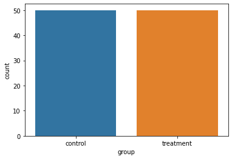

```python
#countplot to show how many people wer in the control group and treatment group.
sns.countplot(data=df, x='group')
plt.show()
```

# Landing page

```python
df['landing_page'].value_counts()
```

```
old    50
new    50
Name: landing_page, dtype: int64
```

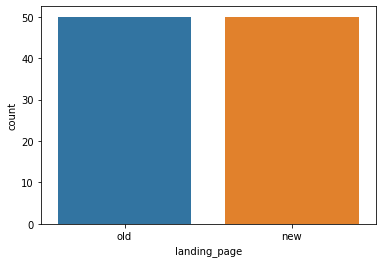

```python
#countplot to show the number of people on the new landing page and the old landing page.
sns.countplot(data=df, x = 'landing_page')
plt.show()
```

# Converted

```python
#count of people converted
df['converted'].value_counts()
```

```
yes    54
no     46
Name: converted, dtype: int64
```

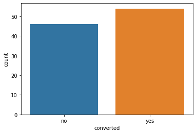

```python
#univariate look at converted yes or no

sns.countplot(data=df,x='converted')
plt.show()
```

# Language preferred

```python
#count of language preferrences
df['language_preferred'].value_counts()
```

```
Spanish    34
French     34
English    32
Name: language_preferred, dtype: int64
```

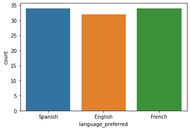

```python
#univariate look at language preferred

sns.countplot(data=df,x='language_preferred')
plt.show()
```

Observations:

1. population is 50/50 Control or Treatment
2. Population is 50/50 New or Old landing page
3. Time spent on the page is close to normal distribution
4. Median time on the page is over 5 minutes
5. 75% of users spend between 4 & 7 minutes on the page
6. A little over half the population is converted
7. There are three different languages: Spanish/French/Englist. They are close to evenly distributed.

# Landing page vs Time spend on the page

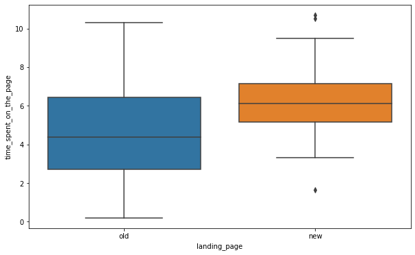

```python
plt.figure(figsize=(10,6))
sns.boxplot(data=df, x='landing_page', y='time_spent_on_the_page')
plt.show()
```

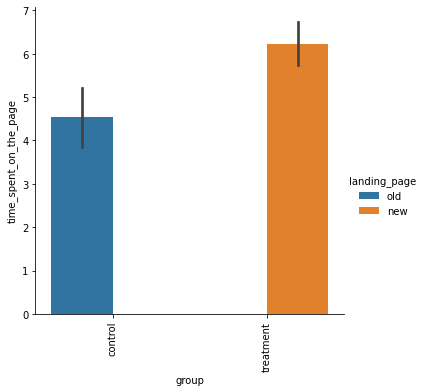

```python
#plot to show cuisine type and cost of order for the weekdays and weekends
sns.catplot(x='group', y='time_spent_on_the_page', data=df, kind="bar", hue='landing_page')
plt.xticks(rotation=90)
plt.show()
```

# Language preferred

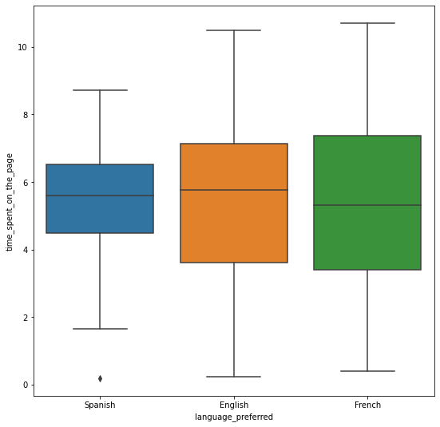

```python
#plot to show language preferred vs time spent on the page
plt.figure(figsize=(9,9))
sns.boxplot(data=df, x = 'language_preferred', y= 'time_spent_on_the_page')
plt.show()
```

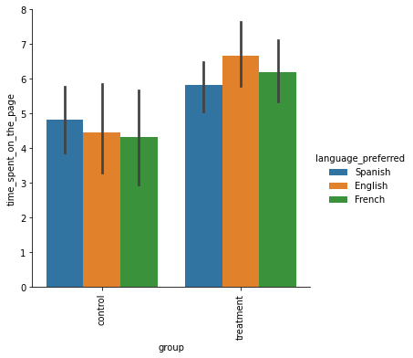

```python
#plot to show group, language and time spent on page
sns.catplot(x='group', y='time_spent_on_the_page', data=df, kind="bar", hue='language_preferred')
plt.xticks(rotation=90)
plt.show()
```

# Conversion status vs Time spent on the page

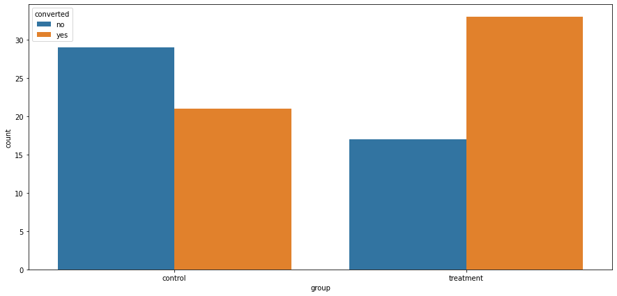

```python
#plot to show count of converted by group
plt.figure(figsize=(15, 7))
sns.countplot(data= df, x= "group", hue='converted');
```

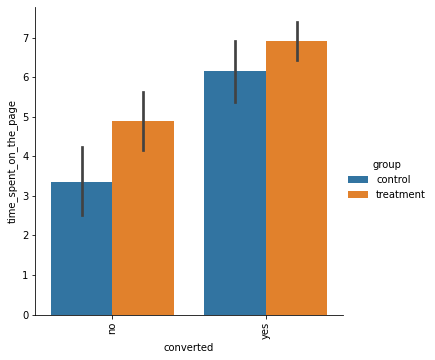

```python
#plot to show time spent in relation to converted
sns.catplot(x='converted', y='time_spent_on_the_page', data=df, kind="bar", hue='group')
plt.xticks(rotation=90)
plt.show()
```

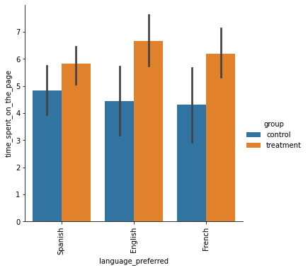

```python
#plot to show time spent in relation to language and group
sns.catplot(x='language_preferred', y='time_spent_on_the_page', data=df, kind="bar", hue='group')
plt.xticks(rotation=90)
plt.show()
```

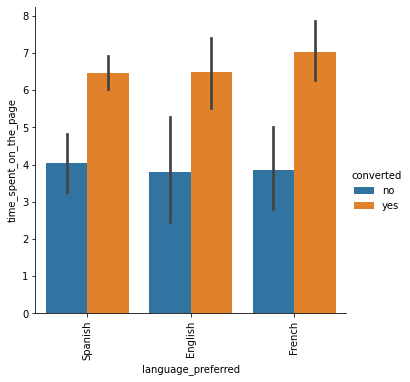

```python
#plot to show time spent in relation to language and converted or not
sns.catplot(x='language_preferred', y='time_spent_on_the_page', data=df, kind="bar", hue='converted')
plt.xticks(rotation=90)
plt.show()
```

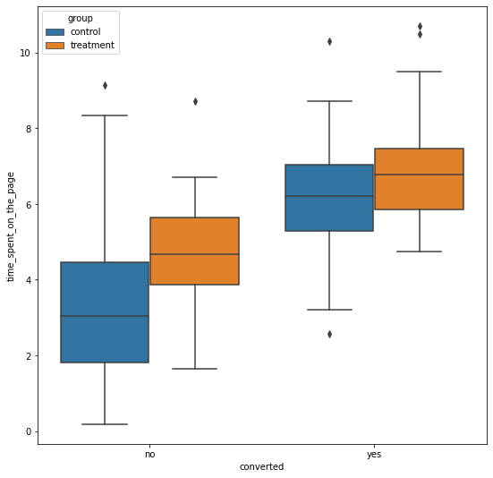

```python
#look at the relationship between converted vs time spent on the page
plt.figure(figsize=(9,9))
sns.boxplot(data = df, x = 'converted', y = 'time_spent_on_the_page', hue = "group")
plt.show()
```

## Observations:

1. the treatment group spent more time on the page
2. More of the treatment group were converted
3. Converted group spent more time on the page
4. Language preference doesn't appear to affect conversion rate
5. Slight difference between language and time spent on page

## 1. Do the users spend more time on the new landing page than the existing landing page?

### Perform Visual Analysis

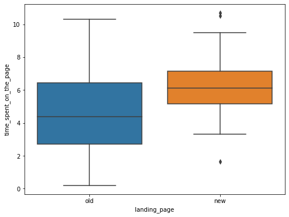

```python
#visual analysis of time spent on the new page and time spent on the old page
plt.figure(figsize=(8,6))
sns.boxplot(x = 'landing_page', y = 'time_spent_on_the_page', data = df)
plt.show()
```

### Step 1: Define the null and alternate hypotheses

### The null and alternative hypothesis

Let $\mu_1, \mu_2$ be the mean time spent on the existing landing page and the new landing page respectively.

We want to test whether there is an increase in the amount of time spent on the new landing page.

We will test the null hypothesis

> $H_0:\mu_1=\mu_2$

against the alternate hypothesis

> $H_a:\mu_1<\mu_2$

### Step 2: Select Appropriate test

# **Two Independent Sample T-test for Equality of Means - Unequal Std Dev**

### Let's test whether the T-test assumptions are satisfied or not

- Continuous data - Yes, the time spent on the page is measured on a continuous scale.
- Normally distributed populations - Yes, we are informed that the populations are assumed to be normal.
- Independent populations - As we are taking random samples for two different groups, the two samples are from two independent populations.
- Unequal population standard deviations - As the sample standard deviations are different, the population standard deviations may be assumed to be different.
- Random sampling from the population - Yes, we are informed that the collected sample a simple random sample.

We can use two sample T-test for this problem.

### Step 3: Decide the significance level

The significance level $\alpha$ in this test is 5% or 0.05 as per E-News

### Step 4: Collect and prepare data

```python
#create subsetted data frame for the control group and treatment group.
dfcontrol = df[df['group']=='control']
dftreatment = df[df['group']=='treatment']


diff = np.mean(dfcontrol['time_spent_on_the_page']) - np.mean(dftreatment['time_spent_on_the_page'])
print('The mean of the differences in time spent between the two pages is', diff)
```

```
The mean of the differences in time spent between the two pages is -1.6907999999999994
```

```python
print('The sample standard deviation of the time spent on the new page is:', round(dftreatment['time_spent_on_the_page'].std(),2))
print('The sample standard deviation of the time spent on the old page is:', round(dfcontrol['time_spent_on_the_page'].std(),2))
```

```
The sample standard deviation of the time spent on the new page is: 1.82
The sample standard deviation of the time spent on the old page is: 2.58
```

### Step 5: Calculate the p-value

```python
#import the required functions
from scipy.stats import ttest_ind

# find the p-value
test_stat, p_value = ttest_ind(dfcontrol['time_spent_on_the_page'], dftreatment['time_spent_on_the_page'], equal_var = False,alternative = 'less')
print('The p-value is ', p_value)
```

```
The p-value is  0.0001392381225166549
```

### Step 6: Compare the p-value with $\alpha$

```python
# print the conclusion based on p-value
alpha = 0.05

if p_value < alpha:
    print(f'As the p-value {p_value} is less than the level of significance, we reject the null hypothesis.')
else:
    print(f'As the p-value {p_value} is greater than the level of significance, we fail to reject the null hypothesis.')
```

```
As the p-value 0.0001392381225166549 is less than the level of significance, we reject the null hypothesis.
```

### Step 7: Draw inference

### Insight

As the p-value is much less than the level of significance, the null hypothesis can be rejected. Thus, it may be concluded that there is enough statistical evidence to conclude that there is an increase in the time spent on the landing page from the existing to the new one.

**A similar approach can be followed to answer the other questions.**

## 2. Is the conversion rate (the proportion of users who visit the landing page and get converted) for the new page greater than the conversion rate for the old page?

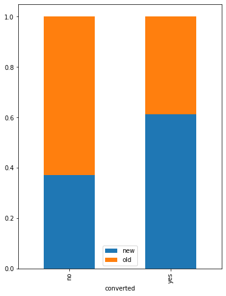

```python
#compare converion rate for the new page and the conversion rate for the old page
pd.crosstab(df['converted'],df['landing_page'],normalize = 'index').plot(kind='bar', figsize=(6,8),stacked=True)
plt.legend()
plt.show()
```

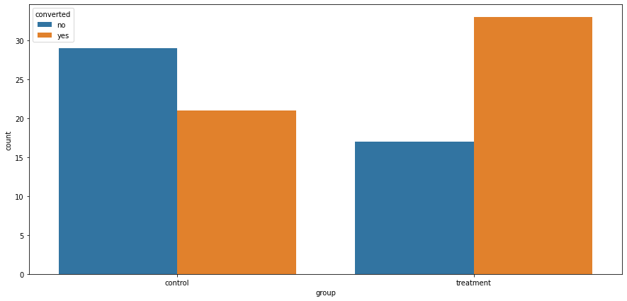

```python
#plot to show count of converted by group
plt.figure(figsize=(15, 7))
sns.countplot(data= df, x= "group", hue='converted');
```

### Let's write the null and alternative hypothesis

Let $p_1,p_2$ be the proportions of converts in the control group and the treatment group respectively.

The manufacturer will test the null hypothesis

> $H_0:p_1 =p_2$

against the alternate hypothesis

> $H_a:p_1 <\ p_2$

```python
#determine the number of users converted from each group.

controlconverted = dfcontrol[dfcontrol['converted']=='yes'].shape[0]
controlconverted #number of control group that converted

treatmentconverted = dftreatment[dftreatment['converted']=='yes'].shape[0]
treatmentconverted #number of treatment group that converted

print(f'The number of converted users from the control group was {controlconverted} and the number of users from the treatement group that were converted was {treatmentconverted}.')
```

```
The number of converted users from the control group was 21 and the number of users from the treatement group that were converted was 33.
```

### Let's test whether the 2 proportion Z-test assumptions are satisfied or not

- Binomally distributed population - Yes, a user is either converted or not converted.
- Random sampling from the population - Yes, we are informed that the collected sample is a simple random sample.
- Can the binomial distribution approximated to normal distribution - Yes. For binary data, CLT works slower than usual. The standard thing is to check whether np and n(1-p) are greater than or equal to 10. Here, n and p refer to the sample size and sample proportion respectively.

  > $np_1 = 50\cdot \frac{21}{50} =21 \geq 10\\ n(1-p_1) = 50 \cdot \frac{50-21}{50} =29 \geq 10 \\ np_2 = 50\cdot \frac{33}{50} =33 \geq 10\\ n(1-p_2) = 50 \cdot \frac{50-33}{50} =17 \geq 10 $

The significance level $\alpha$ in this test is 5% or 0.05 as per E-News

### Calculate the p-value

```python
# import the required fuction
from statsmodels.stats.proportion import proportions_ztest

# set the counts of converted users
defect_count = np.array([controlconverted, treatmentconverted])

# set the sample sizes
nobs = np.array([50, 50])

# find the p-value
test_stat, p_value = proportions_ztest(defect_count, nobs, alternative = 'smaller')
print('The p-value is ' + str(p_value))
```

```
The p-value is 0.008026308204056278
```

### Compare the p-value with $\alpha$

```python
# print the conclusion based on p-value
alpha = 0.05

if p_value < alpha:
    print(f'As the p-value {p_value} is less than the level of significance, we reject the null hypothesis.')
else:
    print(f'As the p-value {p_value} is greater than the level of significance, we fail to reject the null hypothesis.')
```

```
As the p-value 0.008026308204056278 is less than the level of significance, we reject the null hypothesis.
```

### Insight

As the p-value is less than the level of significance, the null hypothesis can be rejected. Thus, it may be concluded that there is enough statistical evidence to conclude that a greater proportion was converted in the treatment group as opposed to the control group.

## 3. Is the conversion and preferred language are independent or related?

# Perform Visual analysis

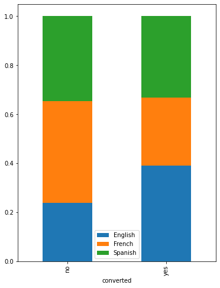

```python
#plot the dependency between conversion status and preferred language.
pd.crosstab(df['converted'],df['language_preferred'],normalize='index').plot(kind="bar",figsize=(6,8), stacked = True)
plt.legend()
plt.show()
```

### Let's write the null and alternative hypothesis

We will test the null hypothesis

> $H_0:$ Conversion rate is independent of preferred language.

against the alternate hypothesis

> $H_a:$ Conversion rate is dependent on preferred language.

# **Chi-Square Test for Independence**

### Let's test whether the assumptions are satisfied or not

- Categorical variables - Yes
- Expected value of the number of sample observations in each level of the variable is at least 5 - Yes, the number of observations in each level is greater than 5.
- Random sampling from the population - Yes, we are informed that the collected sample is a simple random sample.

The significance level $\alpha$ in this test is 5% or 0.05 as per E-News

```python
#create a contingency table based on language preferred
data_crosstab = pd.crosstab(df['language_preferred'],
                            df['converted'])
print(data_crosstab)
```

```
converted           no  yes
language_preferred
English             11   21
French              19   15
Spanish             16   18
```

### Calculate the p-value

```python
# find the p-value

from scipy.stats import chi2_contingency

chi, p_value, dof, expected = chi2_contingency(data_crosstab)
print('The p-value is', p_value)
```

```
The p-value is 0.2129888748754345
```

### Compare the p-value with $\alpha$

```python
# print the conclusion based on p-value
alpha = 0.05

if p_value < alpha:
    print(f'As the p-value {p_value} is less than the level of significance, we reject the null hypothesis.')
else:
    print(f'As the p-value {p_value} is greater than the level of significance, we fail to reject the null hypothesis.')
```

```
As the p-value 0.2129888748754345 is greater than the level of significance, we fail to reject the null hypothesis.
```

## 4. Is the time spent on the new page same for the different language users?

```python
# get the number of users on the new page by language prefernce
dfnewpage = df[df['group']=='treatment']
dfnewpage['language_preferred'].value_counts()
```

```
Spanish    17
French     17
English    16
Name: language_preferred, dtype: int64
```

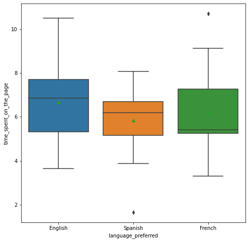

```python
#Plot the time spent on the new page for different language users
plt.figure(figsize=(8,8))
sns.boxplot(x = 'language_preferred', y = 'time_spent_on_the_page', showmeans = True, data = dfnewpage)
plt.show()
```

```python
#calculate the mean time spent on the new page for different language users
dfnewpage.groupby(['language_preferred'])['time_spent_on_the_page'].mean()
```

```
language_preferred
English    6.663750
French     6.196471
Spanish    5.835294
Name: time_spent_on_the_page, dtype: float64
```

### Null and alternative hypothesis

Let $\mu_1, \mu_2, \mu_3$ be the means of the time spend on the new landing page for languages Spanish, French and English respectively.

We will test the null hypothesis

> $H_0: \mu_1 = \mu_2 = \mu_3$

against the alternative hypothesis

> $H_a: $ At least one language group is different in the amount of time spent on the new landing page than the others.

# **One-way ANOVA Test**

The significance level $\alpha$ in this test is 5% or 0.05 as per E-News

# Collect and Prepare Data

The normality and equality of variance assumptions need to be checked.

- For testing of normality, Shapiro-Wilk’s test is applied to the response variable.
- For equality of variance, Levene test is applied to the response variable.

### Shapiro-Wilk’s test

We will test the null hypothesis

> $H_0:$ Time spent on the page follows a normal distribution against

the alternative hypothesis

> $H_a:$ Time spent on the page does not follow a normal distribution

```python
# Assumption 1: Normality
# import the required function
from scipy import stats

# find the p-value
w, p_value = stats.shapiro(dfnewpage['time_spent_on_the_page'])
print('The p-value is', p_value)
```

```
The p-value is 0.8040016293525696
```

Since p-value of the test is very large, we fail to reject the null hypothesis that the response follows the normal distribution.

### Levene’s test

We will test the null hypothesis

> $H_0$: All the population variances are equal

against the alternative hypothesis

> $H_a$: At least one variance is different from the rest

```python
#Assumption 2: Homogeneity of Variance
#import the required function
from scipy.stats import levene
statistic, p_value = levene( dfnewpage['time_spent_on_the_page'][dfnewpage['language_preferred']=="Spanish"],
                                   dfnewpage['time_spent_on_the_page'][dfnewpage['language_preferred']=="French"],
                                   dfnewpage['time_spent_on_the_page'][dfnewpage['language_preferred']=="English"])
# find the p-value
print('The p-value is', p_value)
```

```
The p-value is 0.46711357711340173
```

Since the p-value is larger than $\alpha$, we fail to reject the null hypothesis of homogeneity of variances.

### Let's test whether the assumptions are satisfied or not

- The populations are normally distributed - Yes, the normality assumption is verified using the Shapiro-Wilk’s test.
- Samples are independent simple random samples - Yes, we are informed that the collected sample is a simple random sample.
- Population variances are equal - Yes, the homogeneity of variance assumption is verified using the Levene's test.

### Find the p-value

```python
#import the required function
from scipy.stats import f_oneway

# perform one-way anova test
test_stat, p_value = f_oneway(dfnewpage.loc[dfnewpage['language_preferred'] == 'Spanish', 'time_spent_on_the_page'],
                              dfnewpage.loc[dfnewpage['language_preferred'] == 'French', 'time_spent_on_the_page'],
                              dfnewpage.loc[dfnewpage['language_preferred'] == 'English', 'time_spent_on_the_page'])
print('The p-value is ' + str(p_value))
```

```
The p-value is 0.43204138694325955
```

```python
# print the conclusion based on p-value
alpha = 0.05

if p_value < alpha:
    print(f'As the p-value {p_value} is less than the level of significance, we reject the null hypothesis.')
else:
    print(f'As the p-value {p_value} is greater than the level of significance, we fail to reject the null hypothesis.')
```

```
As the p-value 0.43204138694325955 is greater than the level of significance, we fail to reject the null hypothesis.
```

## Conclusion and Business Recommendations

- Users are spending more time on the new page
- The treatment group has a greater conversion rate than the control group
- Conversion rate is independent of the users preferred language
- Time spent on the new page is independent of preferred language
- Recommend switching all users to the new page for more conversions between all users.

```python
#code to convert to html
%%shell
jupyter nbconvert --to html ///content/drive/MyDrive/Colab_Notebooks/ENews_Express_Learner_Notebook5BFull_Code_Version5D.ipynb
```

```
[NbConvertApp] Converting notebook ///content/drive/MyDrive/Colab_Notebooks/ENews_Express_Learner_Notebook5BFull_Code_Version5D.ipynb to html
[NbConvertApp] Writing 360833 bytes to ///content/drive/MyDrive/Colab_Notebooks/ENews_Express_Learner_Notebook5BFull_Code_Version5D.html
```